# Replication Comparison

Generated 2026-06-08 17:49:22. The report compares existing artifacts only; it does not rerun Stata or update CSV status.

Comparison

## Comparisons

### Table 1: Labor Supply Effects

mismatch

#### Old

| Path | `old_output/tables/com_weekly_attend_b8_attend_work1_frag2.tex` |
| --- | --- |

| Treatment | 1.761 | 0.777 | 0.474 | 0.466 | 0.317 |
| --- | --- | --- | --- | --- | --- |
|  | (0.186) | (0.179) | (0.180) | (0.196) | (0.150) |
|  | [0.000] | [0.000] | [0.009] | [0.019] | [0.036] |
| Control mean | 1.395 | 2.990 | 1.265 | 2.577 | 3.041 |
| N: worker-weeks | 1572 | 1572 | 1800 | 1800 | 1357 |

#### Date Priority

| Path | `output/prioritize_date/tables/table_a.tex` |
| --- | --- |

|  | Phase 1 | Phase 2 |  |  |  |
| --- | --- | --- | --- | --- | --- |
|  | By 8 | Attend | By 8 | Attend | Work |
| Treatment | 1.768 | 0.759 | 0.448 | 0.440 | 0.245 |
|  | (0.186) | (0.178) | (0.179) | (0.200) | (0.152) |
|  | [0.000] | [0.000] | [0.013] | [0.029] | [0.107] |
| Control mean | 1.416 | 3.017 | 1.256 | 2.577 | 3.078 |
| N: worker-weeks | 1572 | 1572 | 1800 | 1800 | 1377 |

### Table 2: Shocks Erode Habit Stock

mismatch

#### Old

| Path | `old_output/tables/shocks_attendloo_b25_feb_3.tex` |
| --- | --- |

|  | (1) | (2) | (3) | (4) | (5) | (6) |
| --- | --- | --- | --- | --- | --- | --- |
| Treat | 0.467 | 0.603 | 0.791 | 0.760 | 0.792 | 0.766 |
|  | (0.196) | (0.220) | (0.243) | (0.257) | (0.243) | (0.259) |
|  | [0.018] | [0.007] | [0.031] | [0.025] | [0.030] | [0.023] |
| [1em] Treat x Post shock |  |  | -0.791 | -0.714 |  |  |
|  |  |  | (0.348) | (0.420) |  |  |
|  |  |  | [0.038] | [0.072] |  |  |
| [1em] Treat x 1 week post shock |  |  |  |  | -0.641 | -0.605 |
|  |  |  |  |  | (0.357) | (0.389) |
|  |  |  |  |  | [0.115] | [0.136] |
| [1em] Treat x 2+ weeks post shock |  |  |  |  | -0.838 | -0.763 |
|  |  |  |  |  | (0.378) | (0.472) |
|  |  |  |  |  | [0.024] | [0.077] |
| [1em] Treat x Second month of phase 2 |  | -0.272 |  |  |  |  |
|  |  | (0.162) |  |  |  |  |
|  |  | [0.095] |  |  |  |  |
| [1em] Treat x Week in phase 2 | -0.0712 |  |  | -0.0339 |  | -0.0289 |
|  | (0.040) |  |  | (0.056) |  | (0.059) |
|  | [0.080] |  |  | [0.617] |  | [0.689] |
| Week in phase FE | Yes | Yes | Yes | Yes | Yes | Yes |
| Calendar Week FE | Yes | Yes | Yes | Yes | Yes | Yes |
| N: worker-weeks | 1800 | 1800 | 1612 | 1612 | 1612 | 1612 |

#### Date Priority

| Path | `output/prioritize_date/tables/table_b.tex` |
| --- | --- |

|  | (1) | (2) | (3) | (4) | (5) | (6) |
| --- | --- | --- | --- | --- | --- | --- |
| Treat | 0.441 | 0.584 | 0.671 | 0.625 | 0.671 | 0.622 |
|  | (0.200) | (0.220) | (0.240) | (0.252) | (0.240) | (0.253) |
|  | [0.028] | [0.009] | [0.179] | [0.231] | [0.179] | [0.233] |
| [1em] Treat x Post shock |  |  | -0.608 | -0.482 |  |  |
|  |  |  | (0.365) | (0.432) |  |  |
|  |  |  | [0.089] | [0.165] |  |  |
| [1em] Treat x 1 week post shock |  |  |  |  | -0.685 | -0.611 |
|  |  |  |  |  | (0.380) | (0.407) |
|  |  |  |  |  | [0.117] | [0.120] |
| [1em] Treat x 2+ weeks post shock |  |  |  |  | -0.580 | -0.427 |
|  |  |  |  |  | (0.402) | (0.488) |
|  |  |  |  |  | [0.079] | [0.228] |
| [1em] Treat x Second month of phase 2 |  | -0.287 |  |  |  |  |
|  |  | (0.161) |  |  |  |  |
|  |  | [0.076] |  |  |  |  |
| [1em] Treat x Week in phase 2 | -0.078 |  |  | -0.057 |  | -0.061 |
|  | (0.040) |  |  | (0.055) |  | (0.058) |
|  | [0.053] |  |  | [0.363] |  | [0.338] |
| Week in phase FE | Yes | Yes | Yes | Yes | Yes | Yes |
| Calendar Week FE | Yes | Yes | Yes | Yes | Yes | Yes |
| N: worker-weeks | 1800 | 1800 | 1620 | 1620 | 1620 | 1620 |

### Table 3: Perceived job finding probability

exact match

#### Old

| Path | `old_output/tables/tu_jfp_8am_short.tex` |
| --- | --- |

|  | (1) | (2) |
| --- | --- | --- |
|  | Days | Days |
| Treatment | 0.0379 | -0.0816 |
|  | (0.219) | (0.223) |
|  | [0.863] | [0.715] |
| Survey date FE | No | Yes |
| Control mean | 4.558 | 4.558 |
| N: worker-survey | 115 | 115 |

#### Date Priority

| Path | `output/prioritize_date/tables/table_c.tex` |
| --- | --- |

|  | (1) | (2) |
| --- | --- | --- |
|  | Days | Days |
| Treatment | 0.0379 | -0.0816 |
|  | (0.219) | (0.223) |
|  | [0.863] | [0.715] |
| Survey date FE | No | Yes |
| Control mean | 4.558 | 4.558 |
| N: worker-survey | 115 | 115 |

### Table 4: Automaticity: Change in Psychological Default

mismatch

#### Old

| Path | `old_output/tables/vig_cog_going_wo_think_attendloo_b25.tex` |
| --- | --- |

| Treatment | 0.308 | 0.467 |
| --- | --- | --- |
|  | (0.151) | (0.181) |
|  | [0.043] | [0.011] |
| Treatment x Post shock |  | -0.655 |
|  |  | (0.355) |
|  |  | [0.067] |
| Control mean | 3.865 | 3.865 |
| N: worker | 175 | 175 |

#### Date Priority

| Path | `output/prioritize_date/tables/table_d.tex` |
| --- | --- |

|  | (1) | (2) |
| --- | --- | --- |
| Treat | .308 | .453 |
|  | (.151) | (.176) |
|  | [.043] | [.011] |
| Treat x Post shock |  | -.693 |
|  |  | (.387) |
|  |  | [.075] |
| Control mean | 3.865 | 3.865 |
| N: worker | 175 | 175 |

### Table 5: No mapped do-file

not applicable

- Orphan — hand-written `.tex` file, no producing code in old or new repo

#### Old

No path.

#### Date Priority

No path.

### Table 6: Willingness to Forgo Flexibility

mismatch

#### Old

| Path | `old_output/tables/flex_fixed_choice_attendloo_b25.tex` |
| --- | --- |

| Treatment | 0.174 | 0.119 | 0.152 |
| --- | --- | --- | --- |
|  | (0.081) | (0.068) | (0.081) |
|  | [0.035] | [0.082] | [0.063] |
| Treatment x Post shock |  |  | -0.123 |
|  |  |  | (0.158) |
|  |  |  | [0.439] |
| Control mean | 0.148 | 0.523 | 0.523 |
| N | 109 | 278 | 278 |

#### Date Priority

| Path | `output/prioritize_date/tables/table_e.tex` |
| --- | --- |

|  | Contract / Job | Fixed choice / No Weight | Fixed choice / Weighted | Fixed choice / Weighted | Fixed choice / No Weight |
| --- | --- | --- | --- | --- | --- |
| Treat |  | 0.130 | 0.152 | 0.131 | 0.148 |
|  |  | (0.067) | (0.071) | (0.080) | (0.085) |
|  |  | [0.053] | [0.034] | [0.103] | [0.086] |
| Treat x Post shock |  |  |  | -0.0650 | -0.0291 |
|  |  |  |  | (0.173) | (0.194) |
|  |  |  |  | [0.707] | [0.881] |
| Control mean | 0.148 | 0.521 | 0.521 | 0.521 | 0.521 |
| N: worker-question | 109 | 294 | 294 | 294 | 294 |

### Table 7: Employer beliefs

exact match

- Multiple old artifacts listed; first existing path is used for the primary preview.

#### Old

| Path | `old_output/stats/med_2wk.tex` |
| --- | --- |

| med_2wk | 55% |
| --- | --- |
| med_2mth | 50% |
| med_4mth | 45% |
| diff_2wk | 19.6% |
| diff_2mth | 11.1% |
| diff_4mth | 50.0% |

#### Date Priority

| Path | `output/prioritize_date/tables/table_f.tex` |
| --- | --- |

| Time Point | Control | Treatment | Treatment | % Change |
| --- | --- | --- | --- | --- |
|  |  |  | (median) |  |
| (1) | (2) | (3) | (4) | (5) |
| 2 Weeks | 46 | 55 | 55 | 19.6% |
| 2 Months | 45 | 50 | 50 | 11.1% |
| 4 Months | 30 | 33 | 45 | 50.0% |

Notes: This table presents results from an incentivized survey with employers where we elicit beliefs regarding the impact of our intervention. Column 1 indicates several time points after the end of Phase 1. Columns 2 and 3 indicate counts of control and treatment participants (out of 100) respectively attending the stand at the different time points, based on the experimental data. Column 4 summarizes employers' median responses to the number of treated workers attending the stand each day at the time points indicated in Column 1, while Column 5 presents the corresponding percentage change in expected attendance between treatment and control participants.

### Table 8: Employer Willingness to Pay for Workers with Habit Stock

exact match

- Multiple old artifacts listed; first existing path is used for the primary preview.

#### Old

| Path | `old_output/stats/Subsidy_1_mean.tex` |
| --- | --- |

| Subsidy_1_mean | 97.1% |
| --- | --- |
| Subsidy_2_mean | 85.5% |
| Subsidy_3_mean | 82.6% |
| Subsidy_4_mean | 82.6% |
| Subsidy_5_mean | 79.7% |

#### Date Priority

| Path | `output/prioritize_date/tables/table_g.tex` |
| --- | --- |

| Subsidy: untrained (INR) | 300 | 300 | 300 | 300 | 300 |
| --- | --- | --- | --- | --- | --- |
| Subsidy: trained (INR) | 300 | 250-275 | 200-250 | 150-225 | 100-200 |
| % choose trained | 97.1 | 85.5 | 82.6 | 82.6 | 79.7 |

Notes: This table presents results from an incentivized survey with employers where we elicit willingness to pay for trained workers with habit stock.

### Table A.1: Weekly Incentive Amount in Phase 1

mismatch

#### Old

| Path | `old_output/tables/balance_test_incentive_record_only.tex` |
| --- | --- |

| [-1.8ex] |  |  |  |  |  |  |  |  |
| --- | --- | --- | --- | --- | --- | --- | --- | --- |
| [-1.8ex] | (1) | (2) | (3) | (2)-(3) |  |  |  |  |
|  | Total | Control | Treatment | Pairwise t-test |  |  |  |  |
| Variable | N | Mean / (SE) | N | Mean / (SE) | N | Mean / (SE) | N | Mean difference |
| [-1.8ex] Payment Record: Amount Allotted | 1575 | 161.810 | 784 | 163.967 | 791 | 159.671 | 1575 | 4.296 |
|  |  | (2.907) |  | (4.136) |  | (4.087) |  |  |
| [1ex] Payment Record: Amount Paid | 1575 | 151.187 | 784 | 145.804 | 791 | 156.523 | 1575 | -10.720* |
|  |  | (2.991) |  | (4.291) |  | (4.163) |  |  |
| [1ex] |  |  |  |  |  |  |  |  |
| [-1.8ex] \(p<0.1\), \(p<0.05\), \(p<0.01\) |  |  |  |  |  |  |  |  |

#### Date Priority

| Path | `output/prioritize_date/tables/table_h.tex` |
| --- | --- |

| [-1.8ex] |  |  |  |  |  |  |  |  |
| --- | --- | --- | --- | --- | --- | --- | --- | --- |
| [-1.8ex] | (1) | (2) | (3) | (2)-(3) |  |  |  |  |
|  | Total | Control | Treatment | Pairwise t-test |  |  |  |  |
| Variable | N | Mean / (SE) | N | Mean / (SE) | N | Mean / (SE) | N | Mean difference |
| [-1.8ex] Payment Record: Amount Allotted | 1575 | 161.810 | 784 | 163.967 | 791 | 159.671 | 1575 | 4.296 |
|  |  | (2.907) |  | (4.136) |  | (4.087) |  |  |
| [1ex] Payment Record: Amount Paid | 1575 | 151.187 | 784 | 145.804 | 791 | 156.523 | 1575 | -10.720* |
|  |  | (2.991) |  | (4.291) |  | (4.163) |  |  |
| [1ex] |  |  |  |  |  |  |  |  |
| [-1.8ex] * p<0.10, ** p<0.05, *** p<0.01 |  |  |  |  |  |  |  |  |

### Table A.2: Baseline Characteristics

mismatch

#### Old

| Path | `old_output/tables/baseline_treatment_control_balance3col.tex` |
| --- | --- |

|  | (1) | (2) | (3) |
| --- | --- | --- | --- |
|  | Control | Treatment | Regression |
|  | Mean | Mean | P-value |
| Age | 42.45 | 42.63 | 0.60 |
|  | (9.52) | (9.30) |  |
| No schooling | 0.20 | 0.19 | 0.95 |
|  | (0.40) | (0.39) |  |
| Has spouse / children | 0.85 | 0.87 | 0.75 |
|  | (0.36) | (0.33) |  |
| Years at stand | 10.23 | 10.45 | 0.73 |
|  | (8.18) | (7.96) |  |
| Years in current profession | 16.35 | 15.91 | 0.76 |
|  | (10.48) | (9.56) |  |
| Days attended stand | 4.23 | 4.24 | 0.93 |
|  | (1.63) | (1.61) |  |
| Days worked | 4.91 | 4.92 | 0.96 |
|  | (2.17) | (2.43) |  |
| Average daily wage (in rupees) | 843.76 | 840.36 | 0.39 |
|  | (122.26) | (133.66) |  |
| Total earnings (in rupees) | 4162.05 | 4157.08 | 0.79 |
|  | (1986.35) | (2159.64) |  |
| Observations | 112 | 113 |  |

#### Date Priority

| Path | `output/prioritize_date/tables/table_i.tex` |
| --- | --- |

|  | (1) | (2) | (3) |
| --- | --- | --- | --- |
|  | Control | Treatment | Regression |
|  | Mean | Mean | P-value |
| Age | 42.45 | 42.63 | 0.60 |
|  | (9.52) | (9.30) |  |
| No schooling | 0.20 | 0.19 | 0.95 |
|  | (0.40) | (0.39) |  |
| Has spouse / children | 0.85 | 0.87 | 0.75 |
|  | (0.36) | (0.33) |  |
| Years at stand | 10.22 | 10.45 | 0.73 |
|  | (8.18) | (7.96) |  |
| Years in current profession | 16.34 | 15.91 | 0.77 |
|  | (10.48) | (9.56) |  |
| Days attended stand | 4.52 | 4.58 | 0.57 |
|  | (1.53) | (1.41) |  |
| Days worked | 5.25 | 5.30 | 0.86 |
|  | (2.11) | (2.28) |  |
| Average daily wage (in rupees) | 532.86 | 538.88 | 0.93 |
|  | (226.51) | (232.76) |  |
| Total earnings (in rupees) | 4446.43 | 4488.94 | 0.98 |
|  | (1948.25) | (2084.06) |  |
| Observations | 112 | 113 |  |

### Table A.3: Habit formation in Consumption?

mismatch

#### Old

| Path | `old_output/tables/iv_com_weekly_attend_nop1attendance_originaldata.tex` |
| --- | --- |

|  | Attend | By 8 |
| --- | --- | --- |
| Higher Incentive Paid | -0.0754 | 0.0603 |
|  | (0.220) | (0.190) |
|  | [0.732] | [0.751] |
| Control Mean | 2.576 | 1.250 |
| N: worker-weeks | 896 | 896 |

#### Date Priority

| Path | `output/prioritize_date/tables/table_j.tex` |
| --- | --- |

|  | Attend | By 8 |
| --- | --- | --- |
| Higher Incentive Paid | -0.0170 | 0.0912 |
|  | (0.491) | (0.402) |
|  | [0.972] | [0.821] |
| Control Mean | 2.578 | 1.234 |
| N: worker-weeks | 896 | 896 |

### Table A.4: Stand Size and Treatment Intensity

mismatch

#### Old

| Path | `old_output/tables/stand_size_tex_compact_studysample.tex` |
| --- | --- |

| Stand | Workers Approached | Estimated Stand Size | Assigned Treatment | Treatment Intensity |
| --- | --- | --- | --- | --- |
| 1 | 215 | 215 | 16 | .07 |
| 2 | 130 | 349.6 | 11 | .03 |
| 3 | 156 | 231.3 | 7 | .03 |
| 5 | 150 | 197.3 | 9 | .05 |
| 6 | 146 | 172.7 | 7 | .04 |
| 13 | 156 | 376.1 | 8 | .02 |
| 15 | 120 | 230 | 6 | .03 |
| 16 | 177 | 280.2 | 17 | .06 |
| 17 | 266 | 309 | 19 | .06 |
| 18 | 122 | 352 | 9 | .03 |
| 20 | 112 | 154.4 | 4 | .03 |

#### Date Priority

| Path | `output/prioritize_date/tables/table_k.tex` |
| --- | --- |

|  | Workers Approached | Estimated Stand Size | Assigned Treatment | Treatment Intensity |
| --- | --- | --- | --- | --- |
| 1 | 215 | 215.0 | 16 | 0.07 |
| 2 | 130 | 350.0 | 11 | 0.03 |
| 3 | 156 | 231.0 | 7 | 0.03 |
| 4 | 150 | 197.0 | 9 | 0.05 |
| 5 | 146 | 173.0 | 7 | 0.04 |
| 6 | 156 | 376.0 | 8 | 0.02 |
| 7 | 120 | 230.0 | 6 | 0.03 |
| 8 | 177 | 280.0 | 17 | 0.06 |
| 9 | 266 | 309.0 | 19 | 0.06 |
| 10 | 122 | 352.0 | 9 | 0.03 |
| 11 | 112 | 154.0 | 4 | 0.03 |

### Table A.5: General Equilibrium Effects

mismatch

#### Old

| Path | `old_output/tables/com_weekly_attend_b8_attend_work1_frag2_faq_higher_treat_intensity_exp_originaldata.tex` |
| --- | --- |

|  | Phase 1 | Phase 2 |  |  |  |
| --- | --- | --- | --- | --- | --- |
|  | (1) | (2) | (3) | (4) | (5) |
|  | By 8 | Attend | By 8 | Attend | Work |
| Treatment | 0.557 | 1.333 | 0.266 | 0.436 | 0.483 |
|  | (0.287) | (0.291) | (0.325) | (0.292) | (0.233) |
|  | [0.056] | [0.000] | [0.415] | [0.140] | [0.041] |
| Control mean | 3.085 | 1.461 | 2.731 | 1.314 | 3.033 |
| Treatment Effect (%) | 18.1 | 91.3 | 9.7 | 33.1 | 15.9 |
| N: worker-weeks | 586 | 586 | 672 | 672 | 508 |
|  | (1) | (2) | (3) | (4) | (5) |
| Treatment | 0.927 | 1.970 | 0.577 | 0.504 | 0.220 |
|  | (0.225) | (0.235) | (0.249) | (0.235) | (0.192) |
|  | [0.000] | [0.000] | [0.022] | [0.034] | [0.255] |
| Control mean | 2.939 | 1.360 | 2.495 | 1.238 | 3.046 |
| Treatment Effect (%) | 31.5 | 144.8 | 23.1 | 40.7 | 7.2 |
| N: worker-weeks | 986 | 986 | 1128 | 1128 | 849 |
|  | (1) | (2) | (3) | (4) | (5) |
| P-value | 0.0788 | 0.296 | 0.852 | 0.434 | 0.365 |

#### Date Priority

| Path | `output/prioritize_date/tables/table_l.tex` |
| --- | --- |

|  | Phase 1 | Phase 2 |  |  |  |
| --- | --- | --- | --- | --- | --- |
|  | (1) | (2) | (3) | (4) | (5) |
|  | By 8 | Attend | By 8 | Attend | Work |
| Treatment | 0.545 | 1.375 | 0.213 | 0.404 | 0.432 |
|  | (0.289) | (0.289) | (0.341) | (0.298) | (0.231) |
|  | [0.062] | [0.000] | [0.534] | [0.179] | [0.065] |
| Control mean | 3.111 | 1.513 | 2.728 | 1.317 | 3.066 |
| Treatment Effect (%) | 17.5 | 90.9 | 7.8 | 30.6 | 14.1 |
| N: worker-weeks | 586 | 586 | 672 | 672 | 508 |
|  | (1) | (2) | (3) | (4) | (5) |
| Treatment | 0.889 | 1.952 | 0.544 | 0.471 | 0.118 |
|  | (0.222) | (0.234) | (0.251) | (0.232) | (0.195) |
|  | [0.000] | [0.000] | [0.032] | [0.044] | [0.547] |
| Control mean | 2.967 | 1.364 | 2.497 | 1.223 | 3.085 |
| Treatment Effect (%) | 30.0 | 143.1 | 21.8 | 38.5 | 3.8 |
| N: worker-weeks | 986 | 986 | 1128 | 1128 | 869 |
|  | (1) | (2) | (3) | (4) | (5) |
| P-value | 0.110 | 0.331 | 0.854 | 0.421 | 0.283 |

### Table A.6: Disruptions During Phase 1

mismatch

#### Old

| Path | `old_output/tables/shocks_attend_j25_bootstrap_phase1.tex` |
| --- | --- |

|  | (1) | (2) | (3) | (4) | (5) | (6) |
| --- | --- | --- | --- | --- | --- | --- |
| Treat | 0.778 | 0.873 | 0.942 | 0.919 | 0.942 | 0.923 |
|  | (0.178) | (0.181) | (0.237) | (0.245) | (0.237) | (0.247) |
|  | [0.000] | [0.000] | [0.026] | [0.078] | [0.026] | [0.082] |
| [1em] Treat x Post shock |  |  | -0.383 | -0.319 |  |  |
|  |  |  | (0.339) | (0.360) |  |  |
|  |  |  | [0.416] | [0.614] |  |  |
| [1em] Treat x 1 week post shock |  |  |  |  | -0.219 | -0.226 |
|  |  |  |  |  | (0.364) | (0.363) |
|  |  |  |  |  | [0.623] | [0.613] |
| [1em] Treat x 2+ weeks post shock |  |  |  |  | -0.428 | -0.356 |
|  |  |  |  |  | (0.364) | (0.406) |
|  |  |  |  |  | [0.351] | [0.606] |
| [1em] Treat x Second month of phase 2 |  | -0.224 |  |  |  |  |
|  |  | (0.173) |  |  |  |  |
|  |  | [0.196] |  |  |  |  |
| [1em] Treat x Week in phase 2 | -0.0667 |  |  | -0.0444 |  | -0.0381 |
|  | (0.053) |  |  | (0.061) |  | (0.067) |
|  | [0.213] |  |  | [0.585] |  | [0.661] |
| Week in phase FE | Yes | Yes | Yes | Yes | Yes | Yes |
| Calendar Week FE | Yes | Yes | Yes | Yes | Yes | Yes |
| N: worker-weeks | 1572 | 1572 | 1420 | 1420 | 1420 | 1420 |

#### Date Priority

| Path | `output/prioritize_date/tables/table_m.tex` |
| --- | --- |

|  | (1) | (2) | (3) | (4) | (5) | (6) |
| --- | --- | --- | --- | --- | --- | --- |
| Treat | 0.759 | 0.841 | 0.873 | 0.860 | 0.872 | 0.861 |
|  | (0.177) | (0.179) | (0.217) | (0.225) | (0.217) | (0.226) |
|  | [0.000] | [0.000] | [0.009] | [0.027] | [0.009] | [0.032] |
| [1em] Treat x Post shock |  |  | -0.424 | -0.387 |  |  |
|  |  |  | (0.329) | (0.353) |  |  |
|  |  |  | [0.231] | [0.465] |  |  |
| [1em] Treat x 1 week post shock |  |  |  |  | -0.322 | -0.316 |
|  |  |  |  |  | (0.348) | (0.350) |
|  |  |  |  |  | [0.297] | [0.370] |
| [1em] Treat x 2+ weeks post shock |  |  |  |  | -0.464 | -0.421 |
|  |  |  |  |  | (0.365) | (0.408) |
|  |  |  |  |  | [0.206] | [0.480] |
| [1em] Treat x Second month of phase 1 |  | -0.192 |  |  |  |  |
|  |  | (0.174) |  |  |  |  |
|  |  | [0.272] |  |  |  |  |
| [1em] Treat x Week in phase 1 | -0.0572 |  |  | -0.0231 |  | -0.0217 |
|  | (0.054) |  |  | (0.061) |  | (0.066) |
|  | [0.289] |  |  | [0.789] |  | [0.815] |
| Week in phase FE | Yes | Yes | Yes | Yes | Yes | Yes |
| Calendar Week FE | Yes | Yes | Yes | Yes | Yes | Yes |
| N: worker-weeks | 1572 | 1572 | 1424 | 1424 | 1424 | 1424 |

### Table A.7: Shock Analysis Robustness column 3

mismatch

#### Old

| Path | `old_output/tables/shocks_analysis_col_3_robustness_originaldata.tex` |
| --- | --- |

|  | (1) | (2) | (3) | (4) | (5) | (6) | (7) |
| --- | --- | --- | --- | --- | --- | --- | --- |
|  | Main / Spec | Lasso / Residual | 20th / Percentile / Threshold | 30th / Percentile / Threshold | Residual / Baseline / Only | 4-Day / Rolling / Average | 7-Day / Rolling / Average |
| Treat | 0.791 | 0.786 | 0.731 | 0.811 | 0.803 | 0.833 | 0.773 |
|  | (0.243) | (0.241) | (0.222) | (0.253) | (0.246) | (0.232) | (0.234) |
|  | [0.031] | [0.102] | [0.077] | [0.072] | [0.075] | [0.043] | [0.076] |
| Treat x Post shock | -0.791 | -0.716 | -0.760 | -0.756 | -0.785 | -0.882 | -0.745 |
|  | (0.348) | (0.336) | (0.372) | (0.339) | (0.346) | (0.341) | (0.377) |
|  | [0.038] | [0.070] | [0.050] | [0.056] | [0.056] | [0.048] | [0.073] |
| Week in phase FE | Yes | Yes | Yes | Yes | Yes | Yes | Yes |
| Calendar Week FE | Yes | Yes | Yes | Yes | Yes | Yes | Yes |
| N: worker-weeks | 1612 | 1618 | 1637 | 1605 | 1612 | 1618 | 1636 |

#### Date Priority

| Path | `output/prioritize_date/tables/table_n.tex` |
| --- | --- |

|  | (1) | (2) | (3) | (4) | (5) | (6) | (7) |
| --- | --- | --- | --- | --- | --- | --- | --- |
|  | Main / Spec | Lasso / Residual | 20th / Percentile / Threshold | 30th / Percentile / Threshold | Residual / Baseline / Only | 4-Day / Rolling / Average | 7-Day / Rolling / Average |
| Treat | 0.671 | 0.737 | 0.614 | 0.754 | 0.735 | 0.733 | 0.727 |
|  | (0.240) | (0.249) | (0.221) | (0.242) | (0.239) | (0.233) | (0.230) |
|  | [0.179] | [0.081] | [0.174] | [0.105] | [0.081] | [0.074] | [0.060] |
| Treat x Post shock | -0.608 | -0.658 | -0.522 | -0.739 | -0.773 | -0.787 | -0.850 |
|  | (0.365) | (0.349) | (0.388) | (0.348) | (0.370) | (0.375) | (0.406) |
|  | [0.089] | [0.061] | [0.090] | [0.066] | [0.054] | [0.050] | [0.045] |
| Week in phase FE | Yes | Yes | Yes | Yes | Yes | Yes | Yes |
| Calendar Week FE | Yes | Yes | Yes | Yes | Yes | Yes | Yes |
| N: worker-weeks | 1620 | 1619 | 1643 | 1611 | 1619 | 1626 | 1646 |

### Table A.8: Shock Analysis Robustness column 4

mismatch

#### Old

| Path | `old_output/tables/shocks_analysis_col_4_robustness_originaldata.tex` |
| --- | --- |

|  | (1) | (2) | (3) | (4) | (5) | (6) | (7) |
| --- | --- | --- | --- | --- | --- | --- | --- |
|  | Main / Spec | Lasso / Residual | 20th / Percentile / Threshold | 30th / Percentile / Threshold | Residual / Baseline / Only | 4-Day / Rolling / Average | 7-Day / Rolling / Average |
| Treat | 0.760 | 0.741 | 0.697 | 0.779 | 0.775 | 0.819 | 0.754 |
|  | (0.257) | (0.254) | (0.228) | (0.271) | (0.260) | (0.243) | (0.239) |
|  | [0.025] | [0.131] | [0.088] | [0.102] | [0.099] | [0.039] | [0.083] |
| Treat x Post shock | -0.714 | -0.608 | -0.661 | -0.681 | -0.717 | -0.848 | -0.692 |
|  | (0.420) | (0.407) | (0.422) | (0.419) | (0.417) | (0.411) | (0.416) |
|  | [0.072] | [0.155] | [0.108] | [0.122] | [0.094] | [0.064] | [0.115] |
| Treat x Week in phase 2 | -0.0339 | -0.0486 | -0.0500 | -0.0318 | -0.0303 | -0.0148 | -0.0298 |
|  | (0.056) | (0.057) | (0.052) | (0.058) | (0.056) | (0.056) | (0.050) |
|  | [0.617] | [0.460] | [0.394] | [0.681] | [0.650] | [0.823] | [0.641] |
| Week in phase FE | Yes | Yes | Yes | Yes | Yes | Yes | Yes |
| Calendar Week FE | Yes | Yes | Yes | Yes | Yes | Yes | Yes |
| N: worker-weeks | 1612 | 1618 | 1637 | 1605 | 1612 | 1618 | 1636 |

#### Date Priority

| Path | `output/prioritize_date/tables/table_o.tex` |
| --- | --- |

|  | (1) | (2) | (3) | (4) | (5) | (6) | (7) |
| --- | --- | --- | --- | --- | --- | --- | --- |
|  | Main / Spec | Lasso / Residual | 20th / Percentile / Threshold | 30th / Percentile / Threshold | Residual / Baseline / Only | 4-Day / Rolling / Average | 7-Day / Rolling / Average |
| Treat | 0.625 | 0.676 | 0.570 | 0.699 | 0.700 | 0.699 | 0.700 |
|  | (0.252) | (0.265) | (0.226) | (0.259) | (0.253) | (0.243) | (0.234) |
|  | [0.231] | [0.091] | [0.221] | [0.128] | [0.103] | [0.088] | [0.075] |
| Treat x Post shock | -0.482 | -0.510 | -0.384 | -0.606 | -0.680 | -0.692 | -0.763 |
|  | (0.432) | (0.425) | (0.435) | (0.427) | (0.441) | (0.436) | (0.442) |
|  | [0.165] | [0.206] | [0.203] | [0.159] | [0.104] | [0.101] | [0.063] |
| Treat x Week in phase 2 | -0.0573 | -0.0658 | -0.0723 | -0.0580 | -0.0428 | -0.0463 | -0.0522 |
|  | (0.055) | (0.057) | (0.052) | (0.058) | (0.056) | (0.055) | (0.049) |
|  | [0.363] | [0.333] | [0.245] | [0.410] | [0.499] | [0.457] | [0.371] |
| Week in phase FE | Yes | Yes | Yes | Yes | Yes | Yes | Yes |
| Calendar Week FE | Yes | Yes | Yes | Yes | Yes | Yes | Yes |
| N: worker-weeks | 1620 | 1619 | 1643 | 1611 | 1619 | 1626 | 1646 |

### Figure 1: Probability of finding a job by arrival time

mismatch

- Mapped Old figure comm_bs_attend_work_30.pdf; preview uses existing sibling comm_bs_attend_work_30.png.

#### Old

| Path | `old_output/figures/comm_bs_attend_work_30.png` |
| --- | --- |

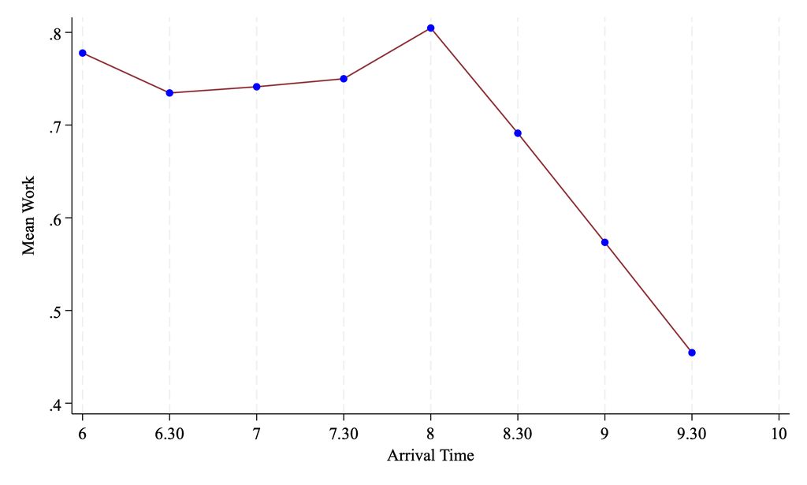

#### Date Priority

| Path | `output/prioritize_date/figures/figure_a.pdf` |
| --- | --- |

[interactive chart not shown]

Open embedded PDF

### Figure 2a: Treatment effect on attendance and arrival time in Phase 1 - Weekly attendance

mismatch

- Mapped Old figure comm_dist_attend_nadj_p1.pdf; preview uses existing sibling comm_dist_attend_nadj_p1.png.

#### Old

| Path | `old_output/figures/comm_dist_attend_nadj_p1.png` |
| --- | --- |

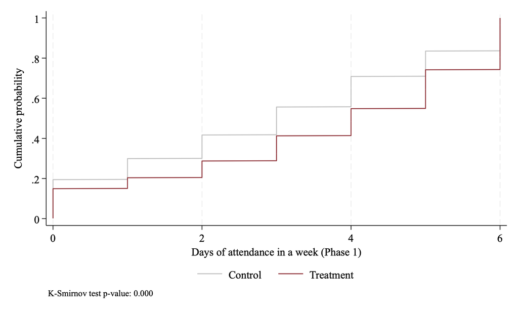

#### Date Priority

| Path | `output/prioritize_date/figures/figure_b_a.pdf` |
| --- | --- |

[interactive chart not shown]

Open embedded PDF

### Figure 2b: Treatment effect on attendance and arrival time in Phase 1 - Arrival time

mismatch

#### Old

| Path | `old_output/figures/hist_arrival_time_by_treatment_p1_daily.pdf` |
| --- | --- |

[interactive chart not shown]

Open embedded PDF

#### Date Priority

| Path | `output/prioritize_date/figures/figure_b_b.pdf` |
| --- | --- |

[interactive chart not shown]

Open embedded PDF

### Figure 3a: Treatment effect in Phase 2 - Weekly attendance

mismatch

- Mapped Old figure comm_dist_attend_nadj_p2.pdf; preview uses existing sibling comm_dist_attend_nadj_p2.png.

#### Old

| Path | `old_output/figures/comm_dist_attend_nadj_p2.png` |
| --- | --- |

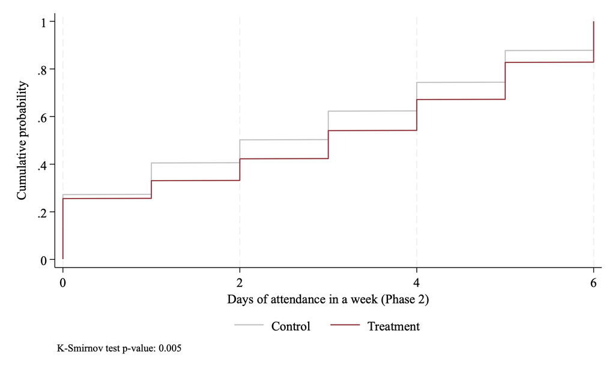

#### Date Priority

| Path | `output/prioritize_date/figures/figure_c_a.pdf` |
| --- | --- |

[interactive chart not shown]

Open embedded PDF

### Figure 3b: Treatment effect in Phase 2 - Arrival time

mismatch

#### Old

| Path | `old_output/figures/hist_arrival_time_by_treatment_p2_daily.pdf` |
| --- | --- |

[interactive chart not shown]

Open embedded PDF

#### Date Priority

| Path | `output/prioritize_date/figures/figure_c_b.pdf` |
| --- | --- |

[interactive chart not shown]

Open embedded PDF

### Figure 4: Attendance over time

mismatch

- Mapped Old figure attend_adj_bs_p1_p2_p3_stand_calweek_v2.pdf; preview uses existing sibling attend_adj_bs_p1_p2_p3_stand_calweek_v2.png.

#### Old

| Path | `old_output/figures/attend_adj_bs_p1_p2_p3_stand_calweek_v2.png` |
| --- | --- |

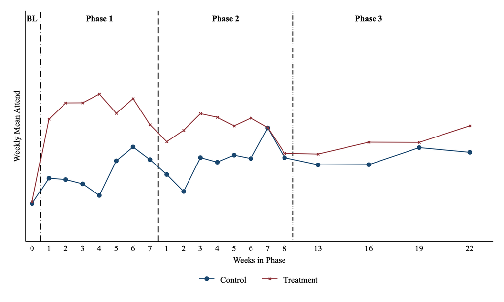

#### Date Priority

| Path | `output/prioritize_date/figures/figure_d.pdf` |
| --- | --- |

[interactive chart not shown]

Open embedded PDF

### Figure 5a: Treatment effect on morning routines - Activities done in the morning

mismatch

- Mapped Old figure bar_morning_activities_low_att.pdf; preview uses existing sibling bar_morning_activities_low_att.png.

#### Old

| Path | `old_output/figures/bar_morning_activities_low_att.png` |
| --- | --- |

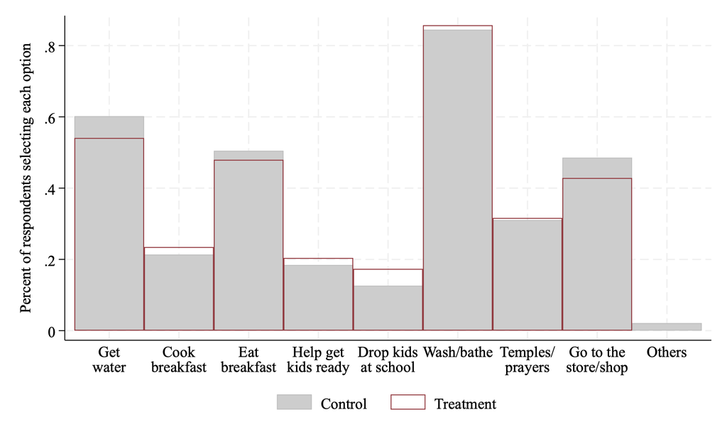

#### Date Priority

| Path | `output/prioritize_date/figures/figure_e_a.pdf` |
| --- | --- |

[interactive chart not shown]

Open embedded PDF

### Figure 5b: Treatment effect on morning routines - Usage of an alarm

mismatch

#### Old

| Path | `old_output/figures/bars_use_alarm.pdf` |
| --- | --- |

[interactive chart not shown]

Open embedded PDF

#### Date Priority

| Path | `output/prioritize_date/figures/figure_e_b.pdf` |
| --- | --- |

[interactive chart not shown]

Open embedded PDF

mismatch

- Mapped Old figure bs_dem_no_ltjob.pdf; preview uses existing sibling bs_dem_no_ltjob.png.

#### Old

| Path | `old_output/figures/bs_dem_no_ltjob.png` |
| --- | --- |

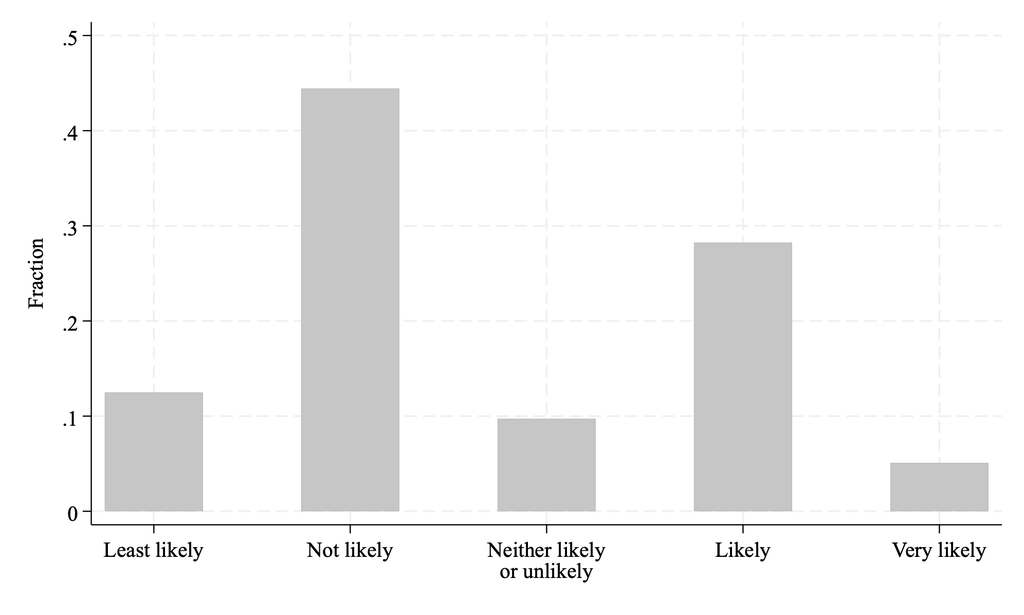

#### Date Priority

| Path | `output/prioritize_date/figures/figure_f_a.pdf` |
| --- | --- |

[interactive chart not shown]

Open embedded PDF

### Figure 6b: Reasons for not wanting a long-term formal job

mismatch

- Mapped Old figure bs_dem_no_ltjob_reasons.pdf; preview uses existing sibling bs_dem_no_ltjob_reasons.png.

#### Old

| Path | `old_output/figures/bs_dem_no_ltjob_reasons.png` |
| --- | --- |

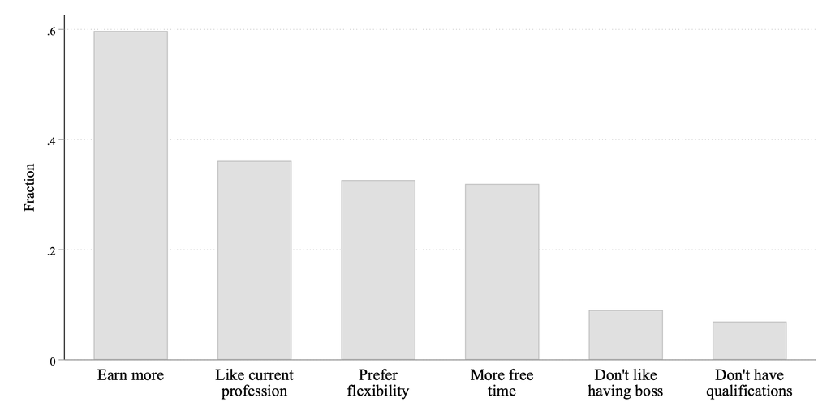

#### Date Priority

| Path | `output/prioritize_date/figures/figure_f_b.pdf` |
| --- | --- |

[interactive chart not shown]

Open embedded PDF

### Figure 7: Predicted worker absenteeism

mismatch

- Mapped Old figure workers_days_off_10.pdf; preview uses existing sibling workers_days_off_10.png.

#### Old

| Path | `old_output/figures/workers_days_off_10.png` |
| --- | --- |

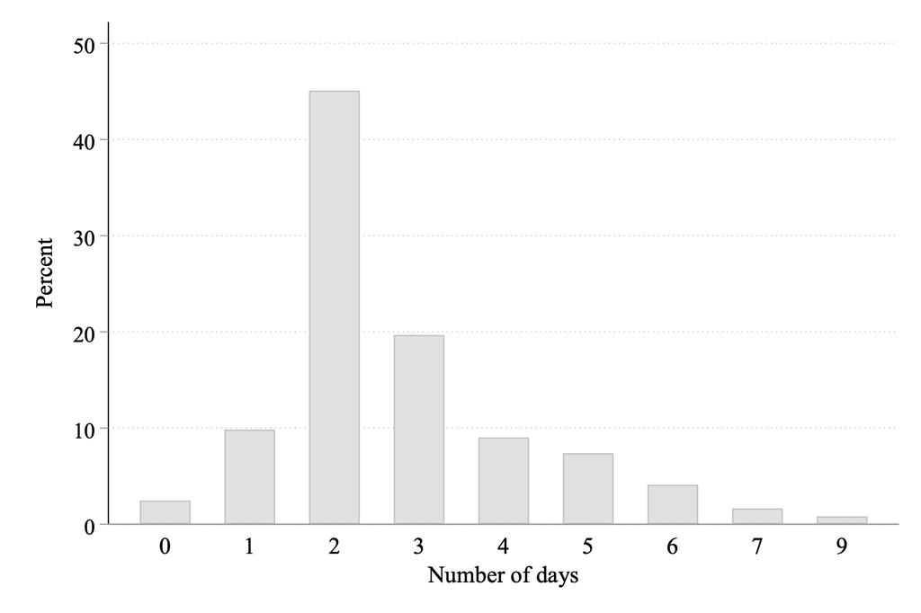

#### Date Priority

| Path | `output/prioritize_date/figures/figure_g.pdf` |
| --- | --- |

[interactive chart not shown]

Open embedded PDF

### Figure 8a: Employer costs - replacement worker time

mismatch

- Mapped Old figure rec_replacement_duration.pdf; preview uses existing sibling rec_replacement_duration.png.

#### Old

| Path | `old_output/figures/rec_replacement_duration.png` |
| --- | --- |

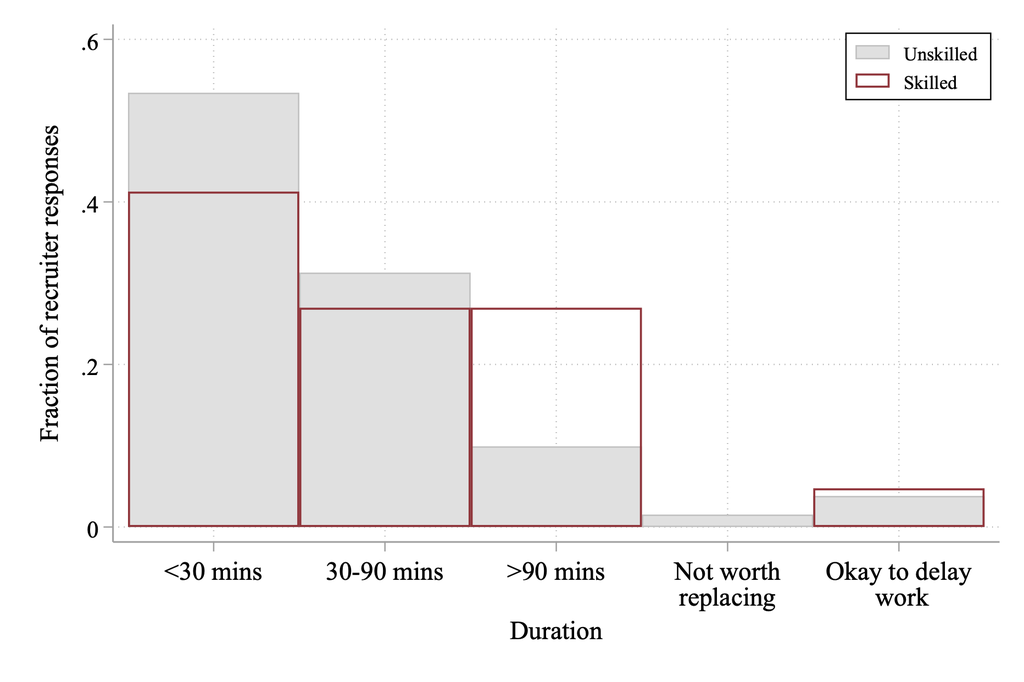

#### Date Priority

| Path | `output/prioritize_date/figures/figure_h_a.pdf` |
| --- | --- |

[interactive chart not shown]

Open embedded PDF

### Figure 8b: Employer costs - onboarding time

mismatch

- Mapped Old figure rec_wrkr_training_duration.pdf; preview uses existing sibling rec_wrkr_training_duration.png.

#### Old

| Path | `old_output/figures/rec_wrkr_training_duration.png` |
| --- | --- |

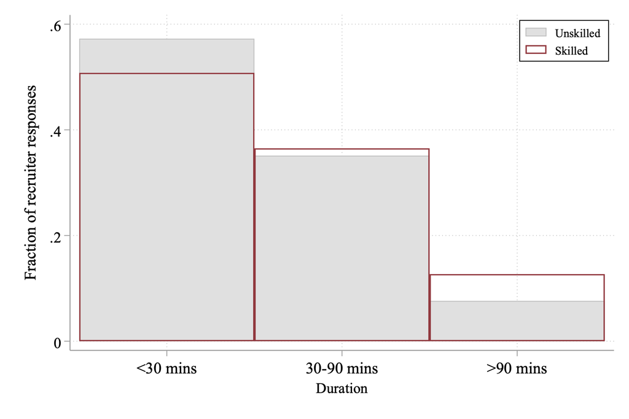

#### Date Priority

| Path | `output/prioritize_date/figures/figure_h_b.pdf` |
| --- | --- |

[interactive chart not shown]

Open embedded PDF

### Figure 9: Labor market structure

mismatch

- Mapped Old figure emp_resp_c7_n7.pdf; preview uses existing sibling emp_resp_c7_n7.png.

#### Old

| Path | `old_output/figures/emp_resp_c7_n7.png` |
| --- | --- |

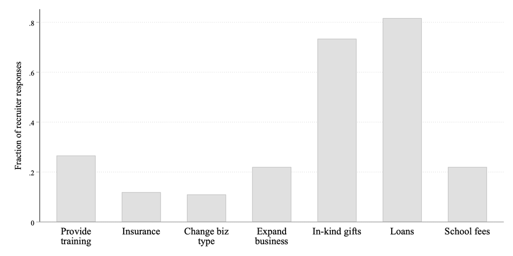

#### Date Priority

| Path | `output/prioritize_date/figures/figure_i.pdf` |
| --- | --- |

[interactive chart not shown]

Open embedded PDF

### Figure A.1 (Treat): Disruption effect robustness - Treat

mismatch

#### Old

| Path | `old_output/figures/treatment_effect_by_shock_threshold_col3_treat_loso_originaldata.pdf` |
| --- | --- |

[interactive chart not shown]

Open embedded PDF

#### Date Priority

| Path | `output/prioritize_date/figures/figure_j_treat.pdf` |
| --- | --- |

[interactive chart not shown]

Open embedded PDF

### Figure A.1 (Treat x Post): Disruption effect robustness - Treat x Post

mismatch

#### Old

| Path | `old_output/figures/treatment_effect_by_shock_threshold_col3_treatpost_loso_originaldata.pdf` |
| --- | --- |

[interactive chart not shown]

Open embedded PDF

#### Date Priority

| Path | `output/prioritize_date/figures/figure_j_treatpost.pdf` |
| --- | --- |

[interactive chart not shown]

Open embedded PDF